# Regressions Project

Luis Calleja

12/20/2014

A car with an automatic transmission has, on average, a higher mpg than cars with manual transmissions when a car is light. However, as a car increases in weight, a manual transmission has a higher mpg performance than an automatic. I arrived at this conclusion by treating the automatic/manual transmission characteristic of a car as an interaction variable to predictive variables weight and quarter second mile time.

```r
anova(lm(mpg~as.factor(cyl),data=mtcars)) #very low
```

```
## Analysis of Variance Table
##
## Response: mpg
##                Df Sum Sq Mean Sq F value    Pr(>F)
## as.factor(cyl)  2 824.78  412.39  39.697 4.979e-09 ***
## Residuals      29 301.26   10.39
## ---
## Signif. codes:  0 '***' 0.001 '**' 0.01 '*' 0.05 '.' 0.1 ' ' 1
```

Running a backward stepwise regression algorithm left out cylinders in favor of quarter second time, which is likely a function of weight, cylinders, transmission and others, but not correlated strongly with any of these, so I took the recommendation and inserted it into the model.

I tried fitting other models with less success as measured by counterintuitive betas and lower adjusted R2. These being:

1. inter.2<-lm(mpg~am.f+wt*qsec,data=n.cars)
- having a positive coefficient for ‘wt’ variable
2. test<-lm(mpg~wt+wt*cyl.f,data=n.cars)
- having an adjusted R2=8349

Lastly on cylinder, if I had chosen to implement it into the model, as a stand alone variable there were few observations across the range of mpg… mpg tended to cluster at exclusive intervals of mpg, so I did not think it would serve well as an interaction variable.

### Intepretation of coefficients

Note: I adjusted the variable ‘weight’ and variable ‘qsec’ down by the size of the smallest observation:

```r
n.cars<-mtcars[,-c(2,9)]
#n.cars<-within(n.cars, cyl.f<-as.factor(cyl) rm(cyl))
n.cars$cyl.f<-as.factor(mtcars$cyl)
n.cars$am.f<-as.factor(mtcars$am)
n.cars$adj.wt<-n.cars$wt-min(n.cars$wt)
n.cars$adj.qsec<-n.cars$qsec-min(n.cars$qsec)
```

[output not shown]

Regression: 20.026 - 2.937*wt +1.017*qsec + 7.814(am=1) - 4.14*wt(am=1)

intercept=20.026: mpg at wt of 1.513 - the lowest wt of the obs & the lowest qsec time (14.5) with a manual transmission

B1=-2.937: the change in mpg for a 1 unit change in wt in the case of a manual transmission

B2=1.017 is the change in mpg for a 1 sec increase in 1/4 mile time, holding wt and transmission type constant

B3=7.814: the change in the intercept should a car be automatic… i.e.the difference in mean mpg across all other variables when a car is automatic

B4=-4.14 is the change in the coefficient to wt for a change in transmission to automatic from manual

### Appendix

The below code shows how number of cylinders tends to cluster around different levels of mpg, however, regressing for weight provides little information

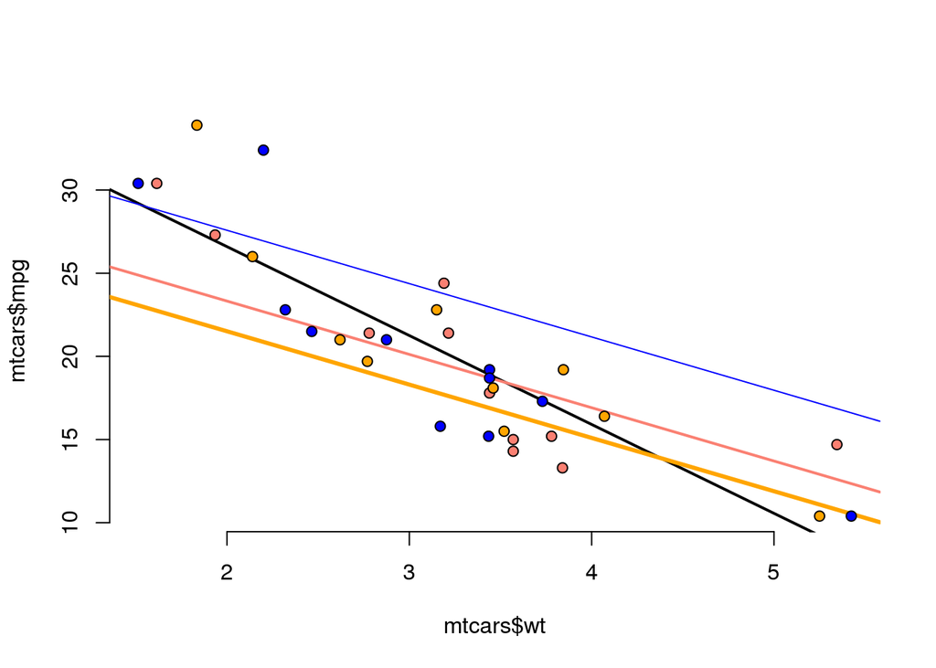

The above reveals that grouping effect is ver hard to discern among cylinders. The above shows how automatic transmission (in salmon) tends to be higher in terms of mpg per weight. The coefficient to weight may also be influenced by transmission type…

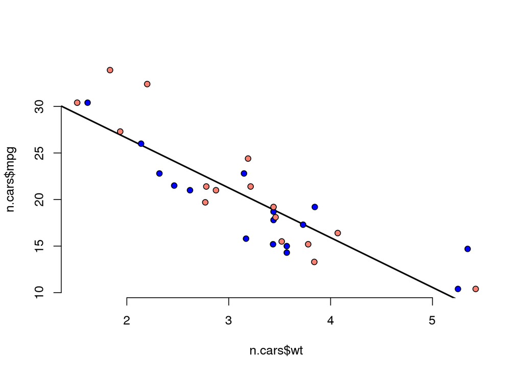

Residuals versus fitted values of mpg:

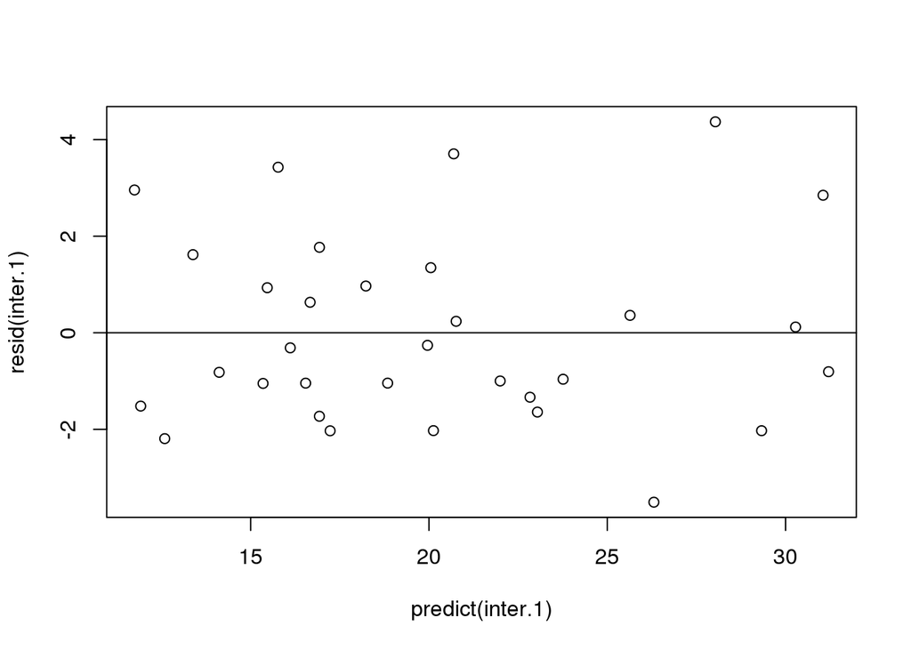